# Data Analytics and Big Data

## 5. Ciencia de Datos con Python

### Task 2. Preparación y Exploración de los Datos

#### Introducción

Credit One, como empresa encargada de ofrecer servicios para determinar la el cumplimiento de los clientes, está perdiendo credibilidad debiido a la gran cantidad de clientes que no cumplen sus cuotas de pago de los préstamos. Por lo tanto, esta empresa desea buscar una solución que permita la disminución de dichos casos.

Para dar comienzo a la solución del problema que se plantea, la empresa brinda un conjunto de datos obtenida de sus clientes para implementar la solución. En el presente documento, se realiza la exploración de los datos que facilita la empresa, con el fin de determinar si alguno de los atributos pueda tener influencia en el pago o no del préstamo y, buscar atributos que ayuden a dar una solución factible al problema.

Para el desarrollo de éste trabajo, se utilizará código en Python, más especificamente, utilizando las bibliotecas de Pandas, Seaborn y Matplotlib.

#### Importar y preparar los datos

Al trabajar con archivos en Python, se utiliza la biblioteca Pandas. Para tener acceso a distintas funciones y métodos que dicha biblioteca ofrece, primero es necesario importarla a nuestro proyecto utilizando el siguiente comando:

```python
import pandas as pd
```

Ahora se tiene acceso a sus funciones o métodos utilizando *pd* para hacer referencia a la biblioteca.

Seguidamente, se procede a leer el archivo que contiene los datos por medio de la función read_csv como se muestra a continuación

```python
credit = pd.read_csv('default of credit card clients.csv', header = 1)
```

En éste caso, se nombró el dataframe como "credit". A continuación, se procede a dar un vistazo rápido a los datos disponibles por medio de la función *head()*

```python
credit.head()
```

|  | ID | LIMIT_BAL | SEX | EDUCATION | MARRIAGE | AGE | PAY_0 | PAY_2 | PAY_3 | PAY_4 | ... | BILL_AMT4 | BILL_AMT5 | BILL_AMT6 | PAY_AMT1 | PAY_AMT2 | PAY_AMT3 | PAY_AMT4 | PAY_AMT5 | PAY_AMT6 | default payment next month |
| --- | --- | --- | --- | --- | --- | --- | --- | --- | --- | --- | --- | --- | --- | --- | --- | --- | --- | --- | --- | --- | --- |
| 0 | 1 | 20000 | 2 | 2 | 1 | 24 | 2 | 2 | -1 | -1 | ... | 0 | 0 | 0 | 0 | 689 | 0 | 0 | 0 | 0 | 1 |
| 1 | 2 | 120000 | 2 | 2 | 2 | 26 | -1 | 2 | 0 | 0 | ... | 3272 | 3455 | 3261 | 0 | 1000 | 1000 | 1000 | 0 | 2000 | 1 |
| 2 | 3 | 90000 | 2 | 2 | 2 | 34 | 0 | 0 | 0 | 0 | ... | 14331 | 14948 | 15549 | 1518 | 1500 | 1000 | 1000 | 1000 | 5000 | 0 |
| 3 | 4 | 50000 | 2 | 2 | 1 | 37 | 0 | 0 | 0 | 0 | ... | 28314 | 28959 | 29547 | 2000 | 2019 | 1200 | 1100 | 1069 | 1000 | 0 |
| 4 | 5 | 50000 | 1 | 2 | 1 | 57 | -1 | 0 | -1 | 0 | ... | 20940 | 19146 | 19131 | 2000 | 36681 | 10000 | 9000 | 689 | 679 | 0 |

5 rows × 25 columns

Seguidamente, se utiliza la función *describe()* con el fin de comprende la composición de los datos

```python
credit.describe()
```

|  | ID | LIMIT_BAL | SEX | EDUCATION | MARRIAGE | AGE | PAY_0 | PAY_2 | PAY_3 | PAY_4 | ... | BILL_AMT4 | BILL_AMT5 | BILL_AMT6 | PAY_AMT1 | PAY_AMT2 | PAY_AMT3 | PAY_AMT4 | PAY_AMT5 | PAY_AMT6 | default payment next month |
| --- | --- | --- | --- | --- | --- | --- | --- | --- | --- | --- | --- | --- | --- | --- | --- | --- | --- | --- | --- | --- | --- |
| count | 30000.000000 | 30000.000000 | 30000.000000 | 30000.000000 | 30000.000000 | 30000.000000 | 30000.000000 | 30000.000000 | 30000.000000 | 30000.000000 | ... | 30000.000000 | 30000.000000 | 30000.000000 | 30000.000000 | 3.000000e+04 | 30000.00000 | 30000.000000 | 30000.000000 | 30000.000000 | 30000.000000 |
| mean | 15000.500000 | 167484.322667 | 1.603733 | 1.853133 | 1.551867 | 35.485500 | -0.016700 | -0.133767 | -0.166200 | -0.220667 | ... | 43262.948967 | 40311.400967 | 38871.760400 | 5663.580500 | 5.921163e+03 | 5225.68150 | 4826.076867 | 4799.387633 | 5215.502567 | 0.221200 |
| std | 8660.398374 | 129747.661567 | 0.489129 | 0.790349 | 0.521970 | 9.217904 | 1.123802 | 1.197186 | 1.196868 | 1.169139 | ... | 64332.856134 | 60797.155770 | 59554.107537 | 16563.280354 | 2.304087e+04 | 17606.96147 | 15666.159744 | 15278.305679 | 17777.465775 | 0.415062 |
| min | 1.000000 | 10000.000000 | 1.000000 | 0.000000 | 0.000000 | 21.000000 | -2.000000 | -2.000000 | -2.000000 | -2.000000 | ... | -170000.000000 | -81334.000000 | -339603.000000 | 0.000000 | 0.000000e+00 | 0.00000 | 0.000000 | 0.000000 | 0.000000 | 0.000000 |
| 25% | 7500.750000 | 50000.000000 | 1.000000 | 1.000000 | 1.000000 | 28.000000 | -1.000000 | -1.000000 | -1.000000 | -1.000000 | ... | 2326.750000 | 1763.000000 | 1256.000000 | 1000.000000 | 8.330000e+02 | 390.00000 | 296.000000 | 252.500000 | 117.750000 | 0.000000 |
| 50% | 15000.500000 | 140000.000000 | 2.000000 | 2.000000 | 2.000000 | 34.000000 | 0.000000 | 0.000000 | 0.000000 | 0.000000 | ... | 19052.000000 | 18104.500000 | 17071.000000 | 2100.000000 | 2.009000e+03 | 1800.00000 | 1500.000000 | 1500.000000 | 1500.000000 | 0.000000 |
| 75% | 22500.250000 | 240000.000000 | 2.000000 | 2.000000 | 2.000000 | 41.000000 | 0.000000 | 0.000000 | 0.000000 | 0.000000 | ... | 54506.000000 | 50190.500000 | 49198.250000 | 5006.000000 | 5.000000e+03 | 4505.00000 | 4013.250000 | 4031.500000 | 4000.000000 | 0.000000 |
| max | 30000.000000 | 1000000.000000 | 2.000000 | 6.000000 | 3.000000 | 79.000000 | 8.000000 | 8.000000 | 8.000000 | 8.000000 | ... | 891586.000000 | 927171.000000 | 961664.000000 | 873552.000000 | 1.684259e+06 | 896040.00000 | 621000.000000 | 426529.000000 | 528666.000000 | 1.000000 |

8 rows × 25 columns

Con el fin de conocer el tipo de dato de cada una de las variables del dataframe, se utiliza la función *info()* de la biblioteca de Pandas de la siguiente manera:

```python
credit.info()
```

```
<class 'pandas.core.frame.DataFrame'>
RangeIndex: 30000 entries, 0 to 29999
Data columns (total 25 columns):
ID                            30000 non-null int64
LIMIT_BAL                     30000 non-null int64
SEX                           30000 non-null int64
EDUCATION                     30000 non-null int64
MARRIAGE                      30000 non-null int64
AGE                           30000 non-null int64
PAY_0                         30000 non-null int64
PAY_2                         30000 non-null int64
PAY_3                         30000 non-null int64
PAY_4                         30000 non-null int64
PAY_5                         30000 non-null int64
PAY_6                         30000 non-null int64
BILL_AMT1                     30000 non-null int64
BILL_AMT2                     30000 non-null int64
BILL_AMT3                     30000 non-null int64
BILL_AMT4                     30000 non-null int64
BILL_AMT5                     30000 non-null int64
BILL_AMT6                     30000 non-null int64
PAY_AMT1                      30000 non-null int64
PAY_AMT2                      30000 non-null int64
PAY_AMT3                      30000 non-null int64
PAY_AMT4                      30000 non-null int64
PAY_AMT5                      30000 non-null int64
PAY_AMT6                      30000 non-null int64
default payment next month    30000 non-null int64
dtypes: int64(25)
memory usage: 5.7 MB
```

Ahora que se le dió un vistazo general a los datos, se procede a realizar el preprocesamiento de los mismos. Esto con el fin de darle un vistazo más profundo enfocándose en el problema.

##### Limpieza y preparación de los datos

Para comenzar con la limpieza de datos, se decide observar si existen valores faltantes en el conjunto de datos. Se decide eliminar los datos del cliente en caso de que exista algún atributo faltante, la función *dropna()* nos permite remover las filas en donde algún atributo presenta valores faltantes (NA/null).

```python
credit.dropna()
```

|  | ID | LIMIT_BAL | SEX | EDUCATION | MARRIAGE | AGE | PAY_0 | PAY_2 | PAY_3 | PAY_4 | ... | BILL_AMT4 | BILL_AMT5 | BILL_AMT6 | PAY_AMT1 | PAY_AMT2 | PAY_AMT3 | PAY_AMT4 | PAY_AMT5 | PAY_AMT6 | default payment next month |
| --- | --- | --- | --- | --- | --- | --- | --- | --- | --- | --- | --- | --- | --- | --- | --- | --- | --- | --- | --- | --- | --- |
| 0 | 1 | 20000 | 2 | 2 | 1 | 24 | 2 | 2 | -1 | -1 | ... | 0 | 0 | 0 | 0 | 689 | 0 | 0 | 0 | 0 | 1 |
| 1 | 2 | 120000 | 2 | 2 | 2 | 26 | -1 | 2 | 0 | 0 | ... | 3272 | 3455 | 3261 | 0 | 1000 | 1000 | 1000 | 0 | 2000 | 1 |
| 2 | 3 | 90000 | 2 | 2 | 2 | 34 | 0 | 0 | 0 | 0 | ... | 14331 | 14948 | 15549 | 1518 | 1500 | 1000 | 1000 | 1000 | 5000 | 0 |
| 3 | 4 | 50000 | 2 | 2 | 1 | 37 | 0 | 0 | 0 | 0 | ... | 28314 | 28959 | 29547 | 2000 | 2019 | 1200 | 1100 | 1069 | 1000 | 0 |
| 4 | 5 | 50000 | 1 | 2 | 1 | 57 | -1 | 0 | -1 | 0 | ... | 20940 | 19146 | 19131 | 2000 | 36681 | 10000 | 9000 | 689 | 679 | 0 |
| ... | ... | ... | ... | ... | ... | ... | ... | ... | ... | ... | ... | ... | ... | ... | ... | ... | ... | ... | ... | ... | ... |
| 29995 | 29996 | 220000 | 1 | 3 | 1 | 39 | 0 | 0 | 0 | 0 | ... | 88004 | 31237 | 15980 | 8500 | 20000 | 5003 | 3047 | 5000 | 1000 | 0 |
| 29996 | 29997 | 150000 | 1 | 3 | 2 | 43 | -1 | -1 | -1 | -1 | ... | 8979 | 5190 | 0 | 1837 | 3526 | 8998 | 129 | 0 | 0 | 0 |
| 29997 | 29998 | 30000 | 1 | 2 | 2 | 37 | 4 | 3 | 2 | -1 | ... | 20878 | 20582 | 19357 | 0 | 0 | 22000 | 4200 | 2000 | 3100 | 1 |
| 29998 | 29999 | 80000 | 1 | 3 | 1 | 41 | 1 | -1 | 0 | 0 | ... | 52774 | 11855 | 48944 | 85900 | 3409 | 1178 | 1926 | 52964 | 1804 | 1 |
| 29999 | 30000 | 50000 | 1 | 2 | 1 | 46 | 0 | 0 | 0 | 0 | ... | 36535 | 32428 | 15313 | 2078 | 1800 | 1430 | 1000 | 1000 | 1000 | 1 |

30000 rows × 25 columns

Seguidamente, se procede a eliminar los atributos que no presentarán algún beneficio o no ofrece aporte alguno en nuestro proyecto, como es el caso del atributo *ID*. Además, con el fin de evitar problemas en el futuro por el tema de discriminación, se elimina el atributo *SEX*. Con el fin de remover dichas columnas, se utiliza la función *drop()*, que permite remover columnas del conjunto de datos.

```python
credit = credit.drop(columns = ['ID','SEX'])
```

Se decide manipular los datos utilizando un conjunto separado

```python
creditDF = credit
```

```python
creditDF.head()
```

|  | LIMIT_BAL | EDUCATION | MARRIAGE | AGE | PAY_0 | PAY_2 | PAY_3 | PAY_4 | PAY_5 | PAY_6 | ... | BILL_AMT4 | BILL_AMT5 | BILL_AMT6 | PAY_AMT1 | PAY_AMT2 | PAY_AMT3 | PAY_AMT4 | PAY_AMT5 | PAY_AMT6 | default payment next month |
| --- | --- | --- | --- | --- | --- | --- | --- | --- | --- | --- | --- | --- | --- | --- | --- | --- | --- | --- | --- | --- | --- |
| 0 | 20000 | 2 | 1 | 24 | 2 | 2 | -1 | -1 | -2 | -2 | ... | 0 | 0 | 0 | 0 | 689 | 0 | 0 | 0 | 0 | 1 |
| 1 | 120000 | 2 | 2 | 26 | -1 | 2 | 0 | 0 | 0 | 2 | ... | 3272 | 3455 | 3261 | 0 | 1000 | 1000 | 1000 | 0 | 2000 | 1 |
| 2 | 90000 | 2 | 2 | 34 | 0 | 0 | 0 | 0 | 0 | 0 | ... | 14331 | 14948 | 15549 | 1518 | 1500 | 1000 | 1000 | 1000 | 5000 | 0 |
| 3 | 50000 | 2 | 1 | 37 | 0 | 0 | 0 | 0 | 0 | 0 | ... | 28314 | 28959 | 29547 | 2000 | 2019 | 1200 | 1100 | 1069 | 1000 | 0 |
| 4 | 50000 | 2 | 1 | 57 | -1 | 0 | -1 | 0 | 0 | 0 | ... | 20940 | 19146 | 19131 | 2000 | 36681 | 10000 | 9000 | 689 | 679 | 0 |

5 rows × 23 columns

Se procede a cambiar los valores de la variable *EDUCATION*, con el fin de tener los 4 valores posibles de la siguiente manera:

- 1: Graduate school
- 2: University
- 3: High school
- 0,4,5,6: Others

```python
creditDF.loc[:, 'EDUCATION'].replace([0, 1, 2, 3, 4, 5, 6], ['Others', 'Graduate school', 'University', 'High school', 'Others', 'Others', 'Others'], inplace=True)
```

De igual manera, se cambian los valores de la variable *MARRIAGE* de la siguiente manera:

- 1: Married
- 2: Single
- 3: Divorce
- 0: Others

```python
creditDF.loc[:, 'MARRIAGE'].replace([0, 1, 2, 3], ['Others', 'Married', 'Single', 'Divorce'], inplace=True)
```

Ahora se dispone de un total de 23 columnas.

Es importante, que los atributos tengan el tipo de variable correcto, del análisis anterior se pudo observar que el tipo de variable en todos los atributos es numérica. Por lo tanto, se procede a cambiar el tipo de variable, a nominal o categórica, en los siguientes atributos: *EDUCATION*, *MARRIAGE*, *PAY_0*, *PAY_2*, *PAY_3*, *PAY_4*, *PAY_5*, *PAY_6* y *default payment next month*.

```python
creditDF = creditDF.astype({'EDUCATION': 'category',
                            'MARRIAGE': 'category',
                            'PAY_0': 'category',
                            'PAY_2': 'category',
                            'PAY_3': 'category',
                            'PAY_4': 'category',
                            'PAY_5': 'category',
                            'PAY_6': 'category',
                            'default payment next month': 'category'})
```

```python
creditDF.info()
```

```
<class 'pandas.core.frame.DataFrame'>
RangeIndex: 30000 entries, 0 to 29999
Data columns (total 23 columns):
LIMIT_BAL                     30000 non-null int64
EDUCATION                     30000 non-null category
MARRIAGE                      30000 non-null category
AGE                           30000 non-null int64
PAY_0                         30000 non-null category
PAY_2                         30000 non-null category
PAY_3                         30000 non-null category
PAY_4                         30000 non-null category
PAY_5                         30000 non-null category
PAY_6                         30000 non-null category
BILL_AMT1                     30000 non-null int64
BILL_AMT2                     30000 non-null int64
BILL_AMT3                     30000 non-null int64
BILL_AMT4                     30000 non-null int64
BILL_AMT5                     30000 non-null int64
BILL_AMT6                     30000 non-null int64
PAY_AMT1                      30000 non-null int64
PAY_AMT2                      30000 non-null int64
PAY_AMT3                      30000 non-null int64
PAY_AMT4                      30000 non-null int64
PAY_AMT5                      30000 non-null int64
PAY_AMT6                      30000 non-null int64
default payment next month    30000 non-null category
dtypes: category(9), int64(14)
memory usage: 3.5 MB
```

En algunas ocasiones es necesario discretizar los datos continuos; es decir, colocar los valores de los atributos en depósitos para que exista un número limitado de estados posibles, los cuales son tratados como si fueran valores ordenados y discretos. Para los datos a disposición, se decide discretizar el atributo *AGE* en 4 depósitos, que abarca lo siguiente:

- Young adults: 15 a 29 años.
- Adults: 30 a 44 años.
- Middle-aged adults: 45 a 59 años.
- Older adults: 60 a 99 años.

El otro atributo modificao es *LIMIT_BAL* en 10 depósitos, con límites cada $100 000, a excepción del último depósito que abarca préstamos muy elevados ya que son muy pocos. La función *pd.cut()* de la biblioteca Pandas permite segmentar los valores de los datos en dichos depósitos.

```python
creditDF['LIMIT_BAL'].describe()
```

```
count      30000.000000
mean      167484.322667
std       129747.661567
min        10000.000000
25%        50000.000000
50%       140000.000000
75%       240000.000000
max      1000000.000000
Name: LIMIT_BAL, dtype: float64
```

```python
creditDF['AGE'].describe()
```

```
count    30000.000000
mean        35.485500
std          9.217904
min         21.000000
25%         28.000000
50%         34.000000
75%         41.000000
max         79.000000
Name: AGE, dtype: float64
```

```python
creditDF['LIMIT_BAL_DISC'] = pd.cut(x = credit['LIMIT_BAL'],
                                          bins = [0, 100000, 200000, 300000, 400000, 500000, 600000, 700000, 800000, 900000, 100000000],
                                          labels = ['Level_1', 'Level_2', 'Level_3', 'Level_4', 'Level_5', 'Level_6', 'Level_7', 'Level_8', 'Level_9', 'Level_10'])
```

```python
creditDF['AGE_DISC'] = pd.cut(x = credit['AGE'],
                                          bins = [15, 30, 45, 60, 99],
                                          labels = ['Young adults', 'Adults', 'Middle-aged adults', 'Older adults'])
```

```python
creditDF.head()
```

|  | LIMIT_BAL | EDUCATION | MARRIAGE | AGE | PAY_0 | PAY_2 | PAY_3 | PAY_4 | PAY_5 | PAY_6 | ... | BILL_AMT6 | PAY_AMT1 | PAY_AMT2 | PAY_AMT3 | PAY_AMT4 | PAY_AMT5 | PAY_AMT6 | default payment next month | LIMIT_BAL_DISC | AGE_DISC |
| --- | --- | --- | --- | --- | --- | --- | --- | --- | --- | --- | --- | --- | --- | --- | --- | --- | --- | --- | --- | --- | --- |
| 0 | 20000 | University | Married | 24 | 2 | 2 | -1 | -1 | -2 | -2 | ... | 0 | 0 | 689 | 0 | 0 | 0 | 0 | 1 | Level_1 | Young adults |
| 1 | 120000 | University | Single | 26 | -1 | 2 | 0 | 0 | 0 | 2 | ... | 3261 | 0 | 1000 | 1000 | 1000 | 0 | 2000 | 1 | Level_2 | Young adults |
| 2 | 90000 | University | Single | 34 | 0 | 0 | 0 | 0 | 0 | 0 | ... | 15549 | 1518 | 1500 | 1000 | 1000 | 1000 | 5000 | 0 | Level_1 | Adults |
| 3 | 50000 | University | Married | 37 | 0 | 0 | 0 | 0 | 0 | 0 | ... | 29547 | 2000 | 2019 | 1200 | 1100 | 1069 | 1000 | 0 | Level_1 | Adults |
| 4 | 50000 | University | Married | 57 | -1 | 0 | -1 | 0 | 0 | 0 | ... | 19131 | 2000 | 36681 | 10000 | 9000 | 689 | 679 | 0 | Level_1 | Middle-aged adults |

5 rows × 25 columns

Con la preparación de datos realizada, es posible continuar con la exploración de los mismo para obtener más información sobre el problema en cuestión y cómo utilizará la ciencia de datos para resolverlo o, al menos, comprenderlo mejor.

##### Análisis exploratorio de los datos

Se ha escrito (Mayo, 2017) que "El análisis de datos exploratorios (EDA) es un aspecto integral de cualquier proyecto de análisis de datos, ciencia de datos o aprendizaje automático. Comprender los datos antes de trabajar con ellos no es solo una buena idea, es una prioridad si planeas lograr algo de importancia ".

EDA generalmente involucra al menos algunos, si no todos, de los siguientes:

- Visualización y estadísticas sobre cada variable (realizado con la función *describe()*.
- Gráficos de dispersión que comparan las relaciones entre dos variables.
- Si es necesario, visualizar la relación entre muchas (más de 2) variables.
- Comprobación de colinealidad o reducción de dimensionalidad

###### Visualizacion de los datos

Con el fin de comprender cómo se distribuyen los datos en cualquier variable única, se procede a utilizar gráficos de barras.

Primeramente, se debe importar la biblioteca *matplotlib* ya que dispone de las mayoría de las principales visualizaciones que se utilizarán.

```python
import matplotlib.pyplot as plt
```

```python
plt.rcParams["figure.figsize"] = (12,8)
```

Ahora se puede obtener visualizaciones para cada uno de los atributos que se necesiten. Se puede obtener el nombre de los atributos con la función *index object* como se muestra a continuación

```python
creditHeader = creditDF.dtypes.index
```

```python
print(creditHeader)
```

```
Index(['LIMIT_BAL', 'EDUCATION', 'MARRIAGE', 'AGE', 'PAY_0', 'PAY_2', 'PAY_3',
       'PAY_4', 'PAY_5', 'PAY_6', 'BILL_AMT1', 'BILL_AMT2', 'BILL_AMT3',
       'BILL_AMT4', 'BILL_AMT5', 'BILL_AMT6', 'PAY_AMT1', 'PAY_AMT2',
       'PAY_AMT3', 'PAY_AMT4', 'PAY_AMT5', 'PAY_AMT6',
       'default payment next month', 'LIMIT_BAL_DISC', 'AGE_DISC'],
      dtype='object')
```

Se construye un histograma por medio del método *.hist()*. A continuación, se muestra el gráfico para el atributo *LIMIT_BAL*

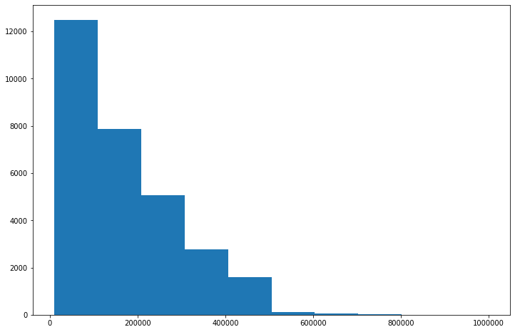

```python
plt.hist(creditDF['LIMIT_BAL'])
plt.show()
```

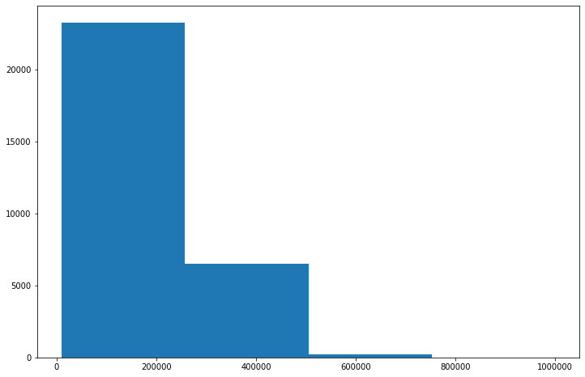

```python
plt.hist(creditDF['LIMIT_BAL'], bins=4)
```

En el gráfico anterior se puede observar que alrededor de 20000 préstamos son menores a los 200000 dólares; es decir, alrededor del 66%. Muy pocos préstamos superan los 600000 dólares y, la mayoría de los préstamos que se otorgan a los clientes son menores a 500000 dólares.

Otra forma de visualizar los datos es por medio de los gráficos de líneas, estos nos permiten ilustrar el rango y el modo de cualquier variable numérica dada. Esto puede ser muy importante para cosas como evitar el sesgo y el sobreajuste del modelo e incluso identificar la colinealidad. Se procede a crear un gráfico lineal para la misma variable anterior.

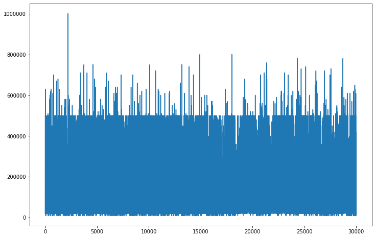

```python
plt.plot(creditDF['LIMIT_BAL'])
plt.show()
```

Del gráfico anterior se puede observar que la mayoría de los préstamos no superan los 500000 dólares, y solamente un caso llega al millón de dólares.

Además de los dos gráficos obtenidos anteriormente, los gráficos de dispersión son muy útiles para comparar dos características entre sí. Esto es muy útil para comprender las posibles relaciones entre los datos, pero no siempre apunta a ninguna relación causal. A continuación, se muestra una comparación entre las variables de *PAY_0* y *PAY_2*.

```python
x = credit['PAY_0']
```

```python
y = credit['PAY_2']
```

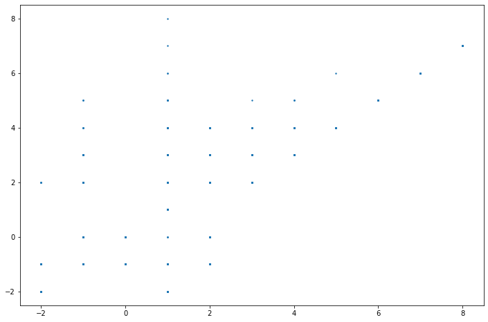

```python
plt.scatter(x,y,s=2)
plt.show()
```

Otra forma de visualización es el gráfico de caja, el cual es muy útil para visualizar rápidamente dónde se encuentra la mayor parte de los datos en cualquier variable dada, y también son muy útiles para identificar características con valores atípicos o variaciones extremas en las observaciones. Procedemos a ver un ejemplo de este tipo de visualización con la variable *BILL_AMT1*

```python
header = creditDF.dtypes.index
print(header)
```

```
Index(['LIMIT_BAL', 'EDUCATION', 'MARRIAGE', 'AGE', 'PAY_0', 'PAY_2', 'PAY_3',
       'PAY_4', 'PAY_5', 'PAY_6', 'BILL_AMT1', 'BILL_AMT2', 'BILL_AMT3',
       'BILL_AMT4', 'BILL_AMT5', 'BILL_AMT6', 'PAY_AMT1', 'PAY_AMT2',
       'PAY_AMT3', 'PAY_AMT4', 'PAY_AMT5', 'PAY_AMT6',
       'default payment next month', 'LIMIT_BAL_DISC', 'AGE_DISC'],
      dtype='object')
```

```python
A = creditDF['BILL_AMT1']
```

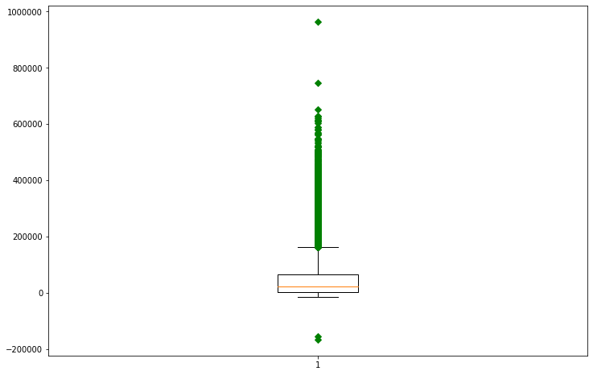

```python
plt.boxplot(A,0,'gD')
plt.show()
```

Del gráfico anterior se puede observar que, la mayoría de las facturas, casi el 100%, para el mes de Setiembre, no superan los 180000 dólares. Además, que un 75% de las facturas de dicho mes, fue menor a los 80000 dólares aproximadamente.

Con el fin de profundizar más en los datos, se procede a realizar otras visualizaciones que nos permitan conocer relaciones entre variables. La primer visiualización consiste en un gráfico que nos permite conocer el porcentaje de personas que pagan y los que no pagan los préstamos

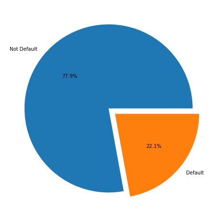

```python
plt.pie(creditDF['default payment next month'].value_counts(dropna=False),labels = ['Not Default','Default'], autopct = '%1.1f%%', explode = (0,0.1))
plt.show()
```

Del gráfico anterior, se observa que un porcentaje muy alto de los clientes posiblemente no pague el mes siguiente (22.1%), lo que evidencia que existe el problema en estudio. Seguidamente, con el fin de visualizar y analizar si existe alguna variable que nos defina con claridad el problema, se procede a realizar distintos gráficos separando la población entre los que posiblemente pagarán y que no pagarán el próximo mes.

Con el fin de separar los datos en dichos grupos, se procede a crear dos nuevos subconjuntos como se muestra a continuación

```python
creditDF_NDP = creditDF[creditDF['default payment next month'] == 0]
```

```python
creditDF_DP = creditDF[creditDF['default payment next month'] == 1]
```

Verificanco los conjuntos

```python
creditDF_NDP['default payment next month'].describe()
```

```
count     23364
unique        1
top           0
freq      23364
Name: default payment next month, dtype: int64
```

```python
creditDF_DP['default payment next month'].describe()
```

```
count     6636
unique       1
top          1
freq      6636
Name: default payment next month, dtype: int64
```

Ahora que se poseen dos subconjuntos, se procede a construir distintas visualizaciones, con el fin de buscar relaciones entre variables. Primeramente, se desea conocer si el límite de préstamo tiene alguna influencia en si la persona paga o no sus cuotas, por lo tanto se comparan ambos grupos utilizando un histograma

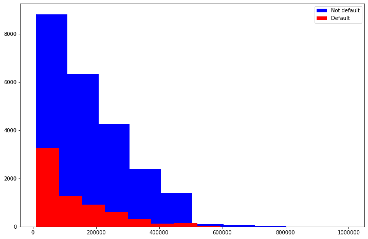

```python
plt.hist(creditDF_NDP['LIMIT_BAL'], color = 'b', label = 'Not default')
plt.hist(creditDF_DP['LIMIT_BAL'], color = 'r', label = 'Default')
plt.legend()
plt.show()
```

Del histograma anterior se puede observar que para los clientes que no pagarán y los que si pagarán el próximo mes, la distribución es la misma; el porcentaje de clientes en ambos grupos disminuye de acuerdo al monto del límite de balance otorgado.

Se procede a obtener los porcentajes de las personas que se espera que paguen y no paguen en el mes siguiente, utilizando la discretización del límite de balance realizado anteriormente.

```python
creditDF.groupby(by = "LIMIT_BAL_DISC", observed = True)['default payment next month'].value_counts()
```

```
LIMIT_BAL_DISC  default payment next month
Level_1         0                             8814
                1                             3684
Level_2         0                             6345
                1                             1535
Level_3         0                             4247
                1                              812
Level_4         0                             2371
                1                              388
Level_5         0                             1404
                1                              194
Level_6         0                              110
                1                               17
Level_7         0                               53
                1                                3
Level_8         0                               19
                1                                3
Level_10        0                                1
Name: default payment next month, dtype: int64
```

De la tabla anterior, se puede observar que no existen créditos otorgados a ningún cliente dentro del *Level_9*, que comprende los valores desde los $800 000 - 900 000 lo que explica su ausencia en la salida anterior. Seguidamente, se construye un gráfico de barras con el fin de observar el comportamiento porcentual de los clientes dentro de cada nivel de préstamo asignado.

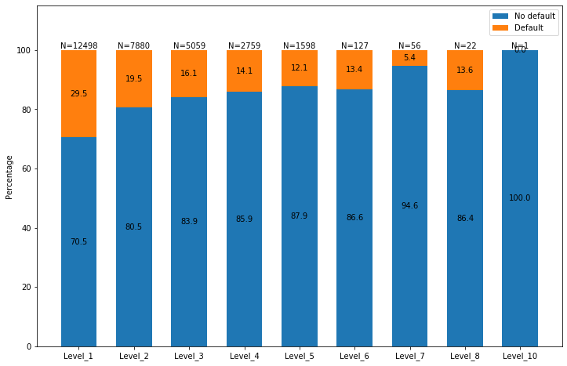

```python
x = ['Level_1', 'Level_2', 'Level_3', 'Level_4', 'Level_5', 'Level_6', 'Level_7', 'Level_8', 'Level_10']
width = 0.65  # the width of the bars
countNDP = creditDF_NDP['LIMIT_BAL_DISC'].value_counts()
countDP = creditDF_DP['LIMIT_BAL_DISC'].value_counts()
snum = creditDF['LIMIT_BAL_DISC'].value_counts()



#normalization
countNDP_nor = (countNDP/snum)*100
countDP_nor = (countDP/snum)*100

countNDP_nor = countNDP_nor.dropna()
countDP_nor = countDP_nor.dropna()

p1 = plt.bar(x,countNDP_nor, width)
p2 = plt.bar(x,countDP_nor, width, bottom = countNDP_nor)


plt.ylabel('Percentage')
plt.legend((p1[2], p2[0]), ('No default', 'Default'))

# add text annotation corresponding to the percentage of each data.
for xpos, ypos, yval in zip(x, countNDP_nor/2, countNDP_nor):
    plt.text(xpos, ypos, "%.1f"%yval, ha="center", va="center")
for xpos, ypos, yval in zip(x, countNDP_nor+countDP_nor/2, countDP_nor):
    plt.text(xpos, ypos, "%.1f"%yval, ha="center", va="center")
# add text annotation corresponding to the "total" value of each bar
for xpos, ypos, yval in zip(x, countNDP_nor+countDP_nor, snum):
    plt.text(xpos, ypos, "N=%d"%yval, ha="center", va="bottom")

plt.ylim(0,115)

plt.show()
```

```python
A =[creditDF_NDP['AGE'], creditDF_DP['AGE']]
```

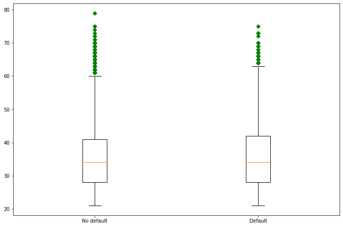

```python
plt.boxplot(A,0,'gD',labels=['No default', 'Default'])
plt.show()
```

En éste caso, no parece que la edad tenga alguna influencia en si la persona pagará o no el préstamo el mes siguiente. En ambos casos, los porcentajes son muy similares, el 75% de las personas que podría pagar o no poseen una edad menor a las 40 años, el 25% restante llega a aproximadamente los 60 años para las personas que pagarán, mientras que para las personas que probablemente no paguen es de aproximadamente 65 años máximo. Sin embargo, en ambos casos existen muchos valores fuera del rango antes mencionado. Por lo tanto, no se observa una clara influencia de la edad en el pago de los préstamos.

A continuación, se procede a analizar el nivel de educación de los clientes, en éste caso se decide utilizar gráficos de pie con el fin de observar el porcentaje de clientes que no pagarán el próximo mes en cada uno de los 4 niveles de *EDUCATION*.

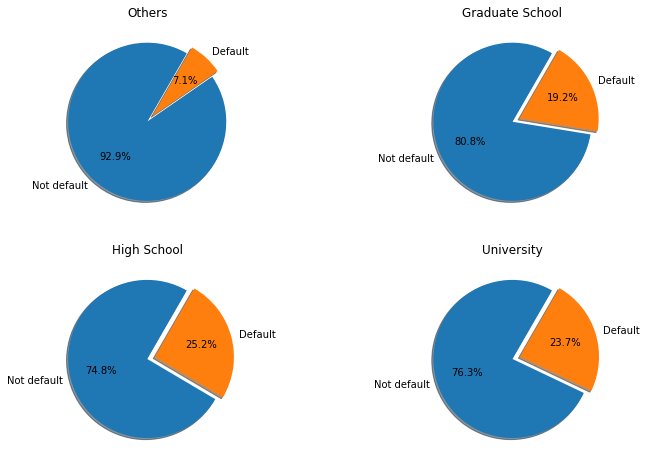

```python
countEduc_NDP = pd.Series(creditDF_NDP['EDUCATION'].value_counts(dropna=False))
countEduc_DP = pd.Series(creditDF_DP['EDUCATION'].value_counts(dropna=False))

labels = 'Not default', 'Default'
countUniversity = [countEduc_NDP.loc['University'], countEduc_DP.loc['University']]
countGraduateSchool = [countEduc_NDP.loc['Graduate school'], countEduc_DP.loc['Graduate school']]
countHighSchool = [countEduc_NDP.loc['High school'], countEduc_DP.loc['High school']]
countOthers = [countEduc_NDP.loc['Others'], countEduc_DP.loc['Others']]
explode = (0, 0.1) # only 'explode' the 2nd slice (i.e. 'Default')

# Make figure and axes
fig, axs = plt.subplots(2,2)

# Pie plots

axs[1, 1].pie(countUniversity, explode=explode, labels=labels, autopct='%1.1f%%',
        shadow=True, startangle=60)
axs[1, 1].set_title("University")
axs[0, 1].pie(countGraduateSchool, explode=explode, labels=labels, autopct='%1.1f%%',
        shadow=True, startangle=60)
axs[0, 1].set_title("Graduate School")
axs[1, 0].pie(countHighSchool, explode=explode, labels=labels, autopct='%1.1f%%',
        shadow=True, startangle=60)
axs[1, 0].set_title("High School")
axs[0, 0].pie(countOthers, explode=explode, labels=labels, autopct='%1.1f%%',
        shadow=True, startangle=60)
axs[0, 0].set_title("Others")
```

```python
creditDF.groupby(by = "EDUCATION", observed = True)['default payment next month'].value_counts()
```

```
EDUCATION        default payment next month
University       0                             10700
                 1                              3330
Graduate school  0                              8549
                 1                              2036
High school      0                              3680
                 1                              1237
Others           0                               435
                 1                                33
Name: default payment next month, dtype: int64
```

A pesar de que no se incluyen en las hipótesis, se procede a analizar algunas variables que pueden mostrar comportamientos que nos indiquen la influencia que tienen en relación a los pagos de los préstamos. Se procede a analizar el estado civil de los clientes.

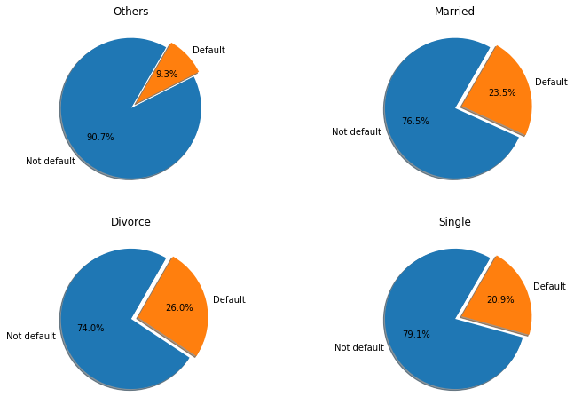

```python
countMarr_NDP = pd.Series(creditDF_NDP['MARRIAGE'].value_counts(dropna=False))
countMarr_DP = pd.Series(creditDF_DP['MARRIAGE'].value_counts(dropna=False))

labels = 'Not default', 'Default'
countSingle = [countMarr_NDP.loc['Single'], countMarr_DP.loc['Single']]
countMarried = [countMarr_NDP.loc['Married'], countMarr_DP.loc['Married']]
countDivorce = [countMarr_NDP.loc['Divorce'], countMarr_DP.loc['Divorce']]
countOthers = [countMarr_NDP.loc['Others'], countMarr_DP.loc['Others']]
explode = (0, 0.1) # only 'explode' the 2nd slice (i.e. 'Default')

# Make figure and axes
fig, axs = plt.subplots(2,2)

# Pie plots

axs[1, 1].pie(countSingle, explode=explode, labels=labels, autopct='%1.1f%%',
        shadow=True, startangle=60)
axs[1, 1].set_title("Single")
axs[0, 1].pie(countMarried, explode=explode, labels=labels, autopct='%1.1f%%',
        shadow=True, startangle=60)
axs[0, 1].set_title("Married")
axs[1, 0].pie(countDivorce, explode=explode, labels=labels, autopct='%1.1f%%',
        shadow=True, startangle=60)
axs[1, 0].set_title("Divorce")
axs[0, 0].pie(countOthers, explode=explode, labels=labels, autopct='%1.1f%%',
        shadow=True, startangle=60)
axs[0, 0].set_title("Others")
```

```python
creditDF.groupby(by = "MARRIAGE", observed = True)['default payment next month'].value_counts()
```

```
MARRIAGE  default payment next month
Married   0                             10453
          1                              3206
Single    0                             12623
          1                              3341
Divorce   0                               239
          1                                84
Others    0                                49
          1                                 5
Name: default payment next month, dtype: int64
```

Del resultado anterior, se puede observar que la gran mayoría de los clientes se encuentran dentro de las categorías "Casado" y "Soltero", menos de 400 clientes se encuentran en las otras dos categorías. Tomando en cuenta los dos grandes grupos, los porcentajes son muy similares, 23.5% para Casado y 20.9% para Soltero. Se observa un ligero incremento en el porcentaje de los clientes que no pagarán el próximo mes a 26% para los clientes divorciados. El porcentaje de clientes que no pagará para la categoría de otros es muy bajo (9.3%), sin embargo, como se menciona anteriormente las observaciones son muy pocas en esta categoría.

Para finalizar con el análisis utilizando visualizaciones de los atributos, se analiza el historial crediticio de los clientes, tomando en cuenta la cantidad de facturas en las cuales el cliente no efectuó ningún pago, lo cual se determino por la resta entre la cantidad de meses en los que el pago fue de 0 dólares y la cantidad de meses en los que el monto de la factura era de 0 dólares. A continuación, se muestran los resultados por medio de gráfico de cajas

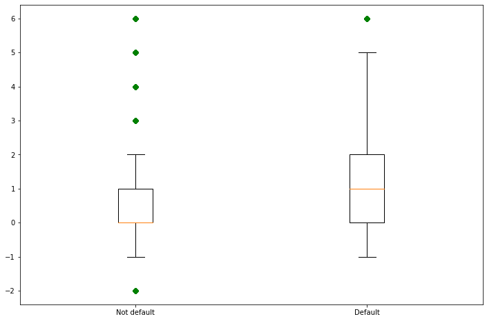

```python
countZeroBill_DP = (creditDF_DP[['BILL_AMT1','BILL_AMT2','BILL_AMT3','BILL_AMT4','BILL_AMT5','BILL_AMT6',]] == 0).astype(int).sum(axis=1)
countZeroPay_DP = (creditDF_DP[['PAY_AMT1','PAY_AMT2','PAY_AMT3','PAY_AMT4','PAY_AMT5','PAY_AMT6',]] == 0).astype(int).sum(axis=1)
countZeroTotal_DP = countZeroPay_DP - countZeroBill_DP
countZeroBill_NDP = (creditDF_NDP[['BILL_AMT1','BILL_AMT2','BILL_AMT3','BILL_AMT4','BILL_AMT5','BILL_AMT6',]] == 0).astype(int).sum(axis=1)
countZeroPay_NDP = (creditDF_NDP[['PAY_AMT1','PAY_AMT2','PAY_AMT3','PAY_AMT4','PAY_AMT5','PAY_AMT6',]] == 0).astype(int).sum(axis=1)
countZeroTotal_NDP = countZeroPay_NDP - countZeroBill_NDP


labels = 'Not default', 'Default'
C = [countZeroTotal_NDP, countZeroTotal_DP]
plt.boxplot(C,0,'gD', labels = labels)
plt.show()
```

Observando el gráfico anterior, el 50% de los clientes que posiblemente pagarán el mes siguiente no dejaron de pagar ninguna de sus facturas en los seis meses que se disponen, el 75% dejaron de pagar solamente una factura, y para el total, como máximo, estos clientes dejaron de pagar dos de sus facturas (25% restante). Además se observan muy pocas observaciones sobrepasan estos 2 meses sin pago.

###### Correlación

La matriz de correlación nos permite revisar la relación que existe entre dos o más caaracterísticas o variables. Cada correlación es un número entre uno negativo y uno positivo. Los números positivos implican asociaciones positivas, mientras que los números negativos implican asociaciones inversas.

A continuación, se procede a trabajar con los datos numéricos con el fin de observar las correlaciones entre los atributos

```python
corrMat = credit.corr()
corrMat
```

|  | LIMIT_BAL | AGE | PAY_0 | PAY_2 | PAY_3 | PAY_4 | PAY_5 | PAY_6 | BILL_AMT1 | BILL_AMT2 | ... | BILL_AMT4 | BILL_AMT5 | BILL_AMT6 | PAY_AMT1 | PAY_AMT2 | PAY_AMT3 | PAY_AMT4 | PAY_AMT5 | PAY_AMT6 | default payment next month |
| --- | --- | --- | --- | --- | --- | --- | --- | --- | --- | --- | --- | --- | --- | --- | --- | --- | --- | --- | --- | --- | --- |
| LIMIT_BAL | 1.000000 | 0.144713 | -0.271214 | -0.296382 | -0.286123 | -0.267460 | -0.249411 | -0.235195 | 0.285430 | 0.278314 | ... | 0.293988 | 0.295562 | 0.290389 | 0.195236 | 0.178408 | 0.210167 | 0.203242 | 0.217202 | 0.219595 | -0.153520 |
| AGE | 0.144713 | 1.000000 | -0.039447 | -0.050148 | -0.053048 | -0.049722 | -0.053826 | -0.048773 | 0.056239 | 0.054283 | ... | 0.051353 | 0.049345 | 0.047613 | 0.026147 | 0.021785 | 0.029247 | 0.021379 | 0.022850 | 0.019478 | 0.013890 |
| PAY_0 | -0.271214 | -0.039447 | 1.000000 | 0.672164 | 0.574245 | 0.538841 | 0.509426 | 0.474553 | 0.187068 | 0.189859 | ... | 0.179125 | 0.180635 | 0.176980 | -0.079269 | -0.070101 | -0.070561 | -0.064005 | -0.058190 | -0.058673 | 0.324794 |
| PAY_2 | -0.296382 | -0.050148 | 0.672164 | 1.000000 | 0.766552 | 0.662067 | 0.622780 | 0.575501 | 0.234887 | 0.235257 | ... | 0.222237 | 0.221348 | 0.219403 | -0.080701 | -0.058990 | -0.055901 | -0.046858 | -0.037093 | -0.036500 | 0.263551 |
| PAY_3 | -0.286123 | -0.053048 | 0.574245 | 0.766552 | 1.000000 | 0.777359 | 0.686775 | 0.632684 | 0.208473 | 0.237295 | ... | 0.227202 | 0.225145 | 0.222327 | 0.001295 | -0.066793 | -0.053311 | -0.046067 | -0.035863 | -0.035861 | 0.235253 |
| PAY_4 | -0.267460 | -0.049722 | 0.538841 | 0.662067 | 0.777359 | 1.000000 | 0.819835 | 0.716449 | 0.202812 | 0.225816 | ... | 0.245917 | 0.242902 | 0.239154 | -0.009362 | -0.001944 | -0.069235 | -0.043461 | -0.033590 | -0.026565 | 0.216614 |
| PAY_5 | -0.249411 | -0.053826 | 0.509426 | 0.622780 | 0.686775 | 0.819835 | 1.000000 | 0.816900 | 0.206684 | 0.226913 | ... | 0.271915 | 0.269783 | 0.262509 | -0.006089 | -0.003191 | 0.009062 | -0.058299 | -0.033337 | -0.023027 | 0.204149 |
| PAY_6 | -0.235195 | -0.048773 | 0.474553 | 0.575501 | 0.632684 | 0.716449 | 0.816900 | 1.000000 | 0.207373 | 0.226924 | ... | 0.266356 | 0.290894 | 0.285091 | -0.001496 | -0.005223 | 0.005834 | 0.019018 | -0.046434 | -0.025299 | 0.186866 |
| BILL_AMT1 | 0.285430 | 0.056239 | 0.187068 | 0.234887 | 0.208473 | 0.202812 | 0.206684 | 0.207373 | 1.000000 | 0.951484 | ... | 0.860272 | 0.829779 | 0.802650 | 0.140277 | 0.099355 | 0.156887 | 0.158303 | 0.167026 | 0.179341 | -0.019644 |
| BILL_AMT2 | 0.278314 | 0.054283 | 0.189859 | 0.235257 | 0.237295 | 0.225816 | 0.226913 | 0.226924 | 0.951484 | 1.000000 | ... | 0.892482 | 0.859778 | 0.831594 | 0.280365 | 0.100851 | 0.150718 | 0.147398 | 0.157957 | 0.174256 | -0.014193 |
| BILL_AMT3 | 0.283236 | 0.053710 | 0.179785 | 0.224146 | 0.227494 | 0.244983 | 0.243335 | 0.241181 | 0.892279 | 0.928326 | ... | 0.923969 | 0.883910 | 0.853320 | 0.244335 | 0.316936 | 0.130011 | 0.143405 | 0.179712 | 0.182326 | -0.014076 |
| BILL_AMT4 | 0.293988 | 0.051353 | 0.179125 | 0.222237 | 0.227202 | 0.245917 | 0.271915 | 0.266356 | 0.860272 | 0.892482 | ... | 1.000000 | 0.940134 | 0.900941 | 0.233012 | 0.207564 | 0.300023 | 0.130191 | 0.160433 | 0.177637 | -0.010156 |
| BILL_AMT5 | 0.295562 | 0.049345 | 0.180635 | 0.221348 | 0.225145 | 0.242902 | 0.269783 | 0.290894 | 0.829779 | 0.859778 | ... | 0.940134 | 1.000000 | 0.946197 | 0.217031 | 0.181246 | 0.252305 | 0.293118 | 0.141574 | 0.164184 | -0.006760 |
| BILL_AMT6 | 0.290389 | 0.047613 | 0.176980 | 0.219403 | 0.222327 | 0.239154 | 0.262509 | 0.285091 | 0.802650 | 0.831594 | ... | 0.900941 | 0.946197 | 1.000000 | 0.199965 | 0.172663 | 0.233770 | 0.250237 | 0.307729 | 0.115494 | -0.005372 |
| PAY_AMT1 | 0.195236 | 0.026147 | -0.079269 | -0.080701 | 0.001295 | -0.009362 | -0.006089 | -0.001496 | 0.140277 | 0.280365 | ... | 0.233012 | 0.217031 | 0.199965 | 1.000000 | 0.285576 | 0.252191 | 0.199558 | 0.148459 | 0.185735 | -0.072929 |
| PAY_AMT2 | 0.178408 | 0.021785 | -0.070101 | -0.058990 | -0.066793 | -0.001944 | -0.003191 | -0.005223 | 0.099355 | 0.100851 | ... | 0.207564 | 0.181246 | 0.172663 | 0.285576 | 1.000000 | 0.244770 | 0.180107 | 0.180908 | 0.157634 | -0.058579 |
| PAY_AMT3 | 0.210167 | 0.029247 | -0.070561 | -0.055901 | -0.053311 | -0.069235 | 0.009062 | 0.005834 | 0.156887 | 0.150718 | ... | 0.300023 | 0.252305 | 0.233770 | 0.252191 | 0.244770 | 1.000000 | 0.216325 | 0.159214 | 0.162740 | -0.056250 |
| PAY_AMT4 | 0.203242 | 0.021379 | -0.064005 | -0.046858 | -0.046067 | -0.043461 | -0.058299 | 0.019018 | 0.158303 | 0.147398 | ... | 0.130191 | 0.293118 | 0.250237 | 0.199558 | 0.180107 | 0.216325 | 1.000000 | 0.151830 | 0.157834 | -0.056827 |
| PAY_AMT5 | 0.217202 | 0.022850 | -0.058190 | -0.037093 | -0.035863 | -0.033590 | -0.033337 | -0.046434 | 0.167026 | 0.157957 | ... | 0.160433 | 0.141574 | 0.307729 | 0.148459 | 0.180908 | 0.159214 | 0.151830 | 1.000000 | 0.154896 | -0.055124 |
| PAY_AMT6 | 0.219595 | 0.019478 | -0.058673 | -0.036500 | -0.035861 | -0.026565 | -0.023027 | -0.025299 | 0.179341 | 0.174256 | ... | 0.177637 | 0.164184 | 0.115494 | 0.185735 | 0.157634 | 0.162740 | 0.157834 | 0.154896 | 1.000000 | -0.053183 |
| default payment next month | -0.153520 | 0.013890 | 0.324794 | 0.263551 | 0.235253 | 0.216614 | 0.204149 | 0.186866 | -0.019644 | -0.014193 | ... | -0.010156 | -0.006760 | -0.005372 | -0.072929 | -0.058579 | -0.056250 | -0.056827 | -0.055124 | -0.053183 | 1.000000 |

21 rows × 21 columns

Obteniendo el "mapa de calor" de las correlaciones

```python
import seaborn as sns
```

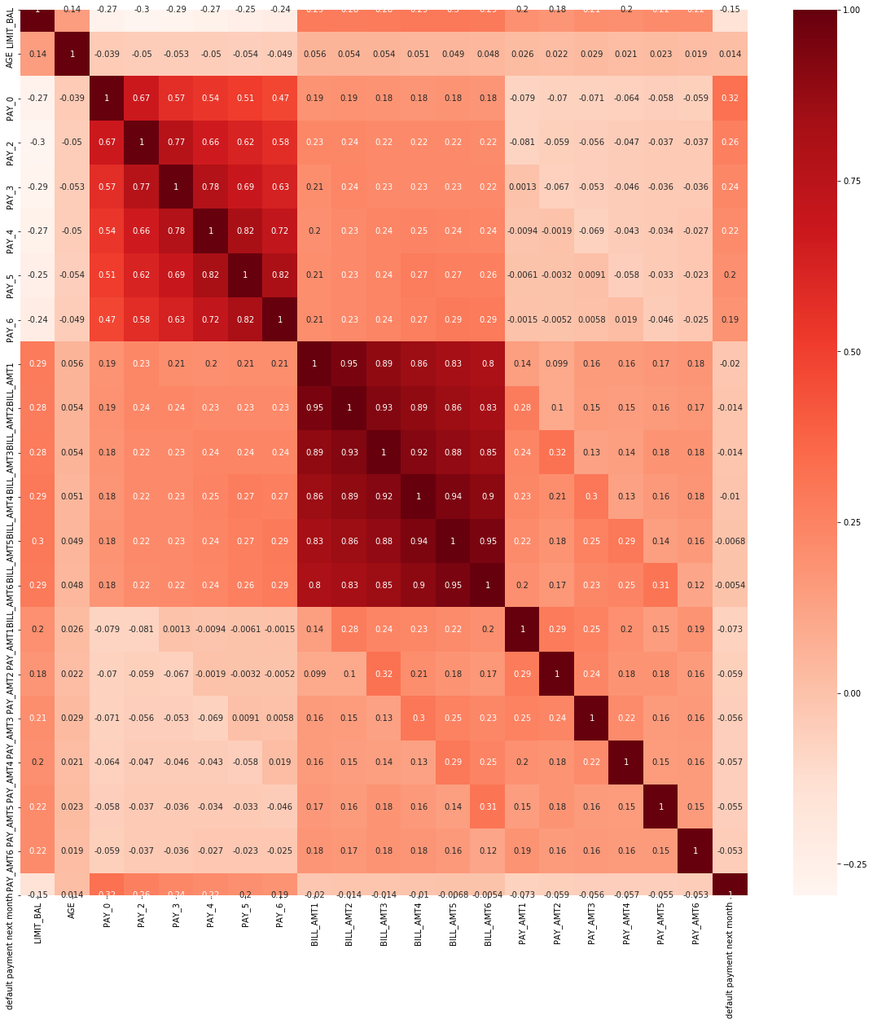

```python
plt.figure(figsize=(20,20))
sns.heatmap(corrMat, annot=True, cmap=plt.cm.Reds)
plt.show()
```

Con el fin de obtener las variables con mayor correlación a la variable dependiente se ejecuta el siguiente comando

```python
cor_target = abs(corrMat['default payment next month'])

#Selecting highly correlated features
relevant_features = cor_target[cor_target>0.1]
relevant_features
```

```
LIMIT_BAL                     0.153520
PAY_0                         0.324794
PAY_2                         0.263551
PAY_3                         0.235253
PAY_4                         0.216614
PAY_5                         0.204149
PAY_6                         0.186866
default payment next month    1.000000
Name: default payment next month, dtype: float64
```

Como se puede observar, los atributos independientes no presentan una correlación alta con la variable dependiente, incluso el atributo con mayor correlación es *PAY_0* con una correlación de 0.32, la cual es baja.

###### Covarianza

La covarianza usualmente se utiliza para medir el grado lineal de cambio entre dos variables. Es decir; se puede usar para medir cómo los cambios en una variable se encuentran asociados a los cambios en una segunda variable. Esto es muy importante para estudiar el impacto que pueden tener varias características en las tasas predeterminadas.

A continuación, se procede a calcular la covarianza

```python
covMat = credit.cov()
covMat
```

|  | LIMIT_BAL | AGE | PAY_0 | PAY_2 | PAY_3 | PAY_4 | PAY_5 | PAY_6 | BILL_AMT1 | BILL_AMT2 | ... | BILL_AMT4 | BILL_AMT5 | BILL_AMT6 | PAY_AMT1 | PAY_AMT2 | PAY_AMT3 | PAY_AMT4 | PAY_AMT5 | PAY_AMT6 | default payment next month |
| --- | --- | --- | --- | --- | --- | --- | --- | --- | --- | --- | --- | --- | --- | --- | --- | --- | --- | --- | --- | --- | --- |
| LIMIT_BAL | 1.683446e+10 | 173076.722569 | -39545.930009 | -46037.648360 | -44432.253315 | -40571.811859 | -36670.562325 | -35093.083441 | 2.727020e+09 | 2.570130e+09 | ... | 2.453926e+09 | 2.331481e+09 | 2.243837e+09 | 4.195711e+08 | 5.333504e+08 | 4.801180e+08 | 4.131202e+08 | 4.305657e+08 | 5.065153e+08 | -8267.551759 |
| AGE | 1.730767e+05 | 84.969755 | -0.408639 | -0.553408 | -0.585263 | -0.535851 | -0.562245 | -0.517022 | 3.817293e+04 | 3.561366e+04 | ... | 3.045311e+04 | 2.765407e+04 | 2.613765e+04 | 3.992042e+03 | 4.626862e+03 | 4.746824e+03 | 3.087324e+03 | 3.218052e+03 | 3.191904e+03 | 0.053143 |
| PAY_0 | -3.954593e+04 | -0.408639 | 1.262930 | 0.904330 | 0.772384 | 0.707972 | 0.648743 | 0.613292 | 1.548030e+04 | 1.518592e+04 | ... | 1.295025e+04 | 1.234167e+04 | 1.184476e+04 | -1.475495e+03 | -1.815138e+03 | -1.396168e+03 | -1.126848e+03 | -9.991077e+02 | -1.172194e+03 | 0.151499 |
| PAY_2 | -4.603765e+04 | -0.553408 | 0.904330 | 1.433254 | 1.098371 | 0.926680 | 0.844886 | 0.792320 | 2.070661e+04 | 2.004583e+04 | ... | 1.711630e+04 | 1.611095e+04 | 1.564288e+04 | -1.600241e+03 | -1.627192e+03 | -1.178331e+03 | -8.788439e+02 | -6.784685e+02 | -7.768350e+02 | 0.130960 |
| PAY_3 | -4.443225e+04 | -0.585263 | 0.772384 | 1.098371 | 1.432492 | 1.087761 | 0.931455 | 0.870815 | 1.837321e+04 | 2.021407e+04 | ... | 1.749410e+04 | 1.638295e+04 | 1.584709e+04 | 2.566847e+01 | -1.841953e+03 | -1.123429e+03 | -8.637622e+02 | -6.557960e+02 | -7.630260e+02 | 0.116867 |
| PAY_4 | -4.057181e+04 | -0.535851 | 0.707972 | 0.926680 | 1.087761 | 1.366885 | 1.086161 | 0.963263 | 1.746020e+04 | 1.879063e+04 | ... | 1.849642e+04 | 1.726555e+04 | 1.665159e+04 | -1.812956e+02 | -5.235817e+01 | -1.425205e+03 | -7.960357e+02 | -5.999916e+02 | -5.521373e+02 | 0.105115 |
| PAY_5 | -3.667056e+04 | -0.562245 | 0.648743 | 0.844886 | 0.931455 | 1.086161 | 1.284114 | 1.064545 | 1.724638e+04 | 1.830129e+04 | ... | 1.982293e+04 | 1.858659e+04 | 1.771569e+04 | -1.142817e+02 | -8.332449e+01 | 1.808121e+02 | -1.034962e+03 | -5.771610e+02 | -4.638926e+02 | 0.096020 |
| PAY_6 | -3.509308e+04 | -0.517022 | 0.613292 | 0.792320 | 0.870815 | 0.963263 | 1.064545 | 1.322472 | 1.756042e+04 | 1.857353e+04 | ... | 1.970555e+04 | 2.033812e+04 | 1.952488e+04 | -2.850067e+01 | -1.383995e+02 | 1.181210e+02 | 3.426237e+02 | -8.158327e+02 | -5.172163e+02 | 0.089194 |
| BILL_AMT1 | 2.727020e+09 | 38172.933546 | 15480.304170 | 20706.614217 | 18373.210469 | 17460.198259 | 17246.377531 | 17560.424872 | 5.422240e+09 | 4.986670e+09 | ... | 4.075286e+09 | 3.714795e+09 | 3.519876e+09 | 1.710894e+08 | 1.685692e+08 | 2.034048e+08 | 1.826164e+08 | 1.879091e+08 | 2.347681e+08 | -600.394108 |
| BILL_AMT2 | 2.570130e+09 | 35613.657962 | 15185.916919 | 20045.829482 | 20214.071495 | 18790.627741 | 18301.285286 | 18573.527165 | 4.986670e+09 | 5.065705e+09 | ... | 4.086508e+09 | 3.720401e+09 | 3.524868e+09 | 3.305146e+08 | 1.653859e+08 | 1.888731e+08 | 1.643518e+08 | 1.717652e+08 | 2.204845e+08 | -419.289137 |
| BILL_AMT3 | 2.548533e+09 | 34334.251320 | 14011.556537 | 18609.510991 | 18882.491544 | 19862.999426 | 19122.663330 | 19234.422476 | 4.556511e+09 | 4.582086e+09 | ... | 4.122238e+09 | 3.726780e+09 | 3.524247e+09 | 2.806565e+08 | 5.064226e+08 | 1.587478e+08 | 1.558003e+08 | 1.904126e+08 | 2.247817e+08 | -405.153680 |
| BILL_AMT4 | 2.453926e+09 | 30453.108180 | 12950.248389 | 17116.298983 | 17494.100555 | 18496.423186 | 19822.925512 | 19705.551629 | 4.075286e+09 | 4.086508e+09 | ... | 4.138716e+09 | 3.677105e+09 | 3.451762e+09 | 2.482888e+08 | 3.076686e+08 | 3.398374e+08 | 1.312133e+08 | 1.576892e+08 | 2.031590e+08 | -271.199885 |
| BILL_AMT5 | 2.331481e+09 | 27654.067800 | 12341.668685 | 16110.952468 | 16382.947539 | 17265.551898 | 18586.590324 | 20338.120325 | 3.714795e+09 | 3.720401e+09 | ... | 3.677105e+09 | 3.696294e+09 | 3.425914e+09 | 2.185501e+08 | 2.538936e+08 | 2.700805e+08 | 2.791830e+08 | 1.315051e+08 | 1.774537e+08 | -170.597447 |
| BILL_AMT6 | 2.243837e+09 | 26137.648547 | 11844.759724 | 15642.875812 | 15847.089648 | 16651.586314 | 17715.690075 | 19524.880348 | 3.519876e+09 | 3.524868e+09 | ... | 3.451762e+09 | 3.425914e+09 | 3.546692e+09 | 1.972478e+08 | 2.369244e+08 | 2.451233e+08 | 2.334670e+08 | 2.799982e+08 | 1.222761e+08 | -132.796294 |
| PAY_AMT1 | 4.195711e+08 | 3992.041735 | -1475.495089 | -1600.240756 | 25.668468 | -181.295613 | -114.281714 | -28.500666 | 1.710894e+08 | 3.305146e+08 | ... | 2.482888e+08 | 2.185501e+08 | 1.972478e+08 | 2.743423e+08 | 1.089849e+08 | 7.354626e+07 | 5.178189e+07 | 3.756893e+07 | 5.469033e+07 | -501.374552 |
| PAY_AMT2 | 5.333504e+08 | 4626.861549 | -1815.138407 | -1627.192336 | -1841.952825 | -52.358166 | -83.324487 | -138.399452 | 1.685692e+08 | 1.653859e+08 | ... | 3.076686e+08 | 2.538936e+08 | 2.369244e+08 | 1.089849e+08 | 5.308817e+08 | 9.929841e+07 | 6.501168e+07 | 6.368414e+07 | 6.456816e+07 | -560.210740 |
| PAY_AMT3 | 4.801180e+08 | 4746.824393 | -1396.168258 | -1178.331282 | -1123.428782 | -1425.205189 | 180.812142 | 118.121022 | 2.034048e+08 | 1.888731e+08 | ... | 3.398374e+08 | 2.700805e+08 | 2.451233e+08 | 7.354626e+07 | 9.929841e+07 | 3.100051e+08 | 5.966970e+07 | 4.282921e+07 | 5.093879e+07 | -411.076284 |
| PAY_AMT4 | 4.131202e+08 | 3087.324192 | -1126.847945 | -878.843879 | -863.762183 | -796.035739 | -1034.961970 | 342.623730 | 1.826164e+08 | 1.643518e+08 | ... | 1.312133e+08 | 2.791830e+08 | 2.334670e+08 | 5.178189e+07 | 6.501168e+07 | 5.966970e+07 | 2.454286e+08 | 3.634098e+07 | 4.395747e+07 | -369.515887 |
| PAY_AMT5 | 4.305657e+08 | 3218.052172 | -999.107730 | -678.468530 | -655.796002 | -599.991629 | -577.161017 | -815.832688 | 1.879091e+08 | 1.717652e+08 | ... | 1.576892e+08 | 1.315051e+08 | 2.799982e+08 | 3.756893e+07 | 6.368414e+07 | 4.282921e+07 | 3.634098e+07 | 2.334266e+08 | 4.207110e+07 | -349.562530 |
| PAY_AMT6 | 5.065153e+08 | 3191.903901 | -1172.193614 | -776.835035 | -763.026041 | -552.137338 | -463.892613 | -517.216277 | 2.347681e+08 | 2.204845e+08 | ... | 2.031590e+08 | 1.774537e+08 | 1.222761e+08 | 5.469033e+07 | 6.456816e+07 | 5.093879e+07 | 4.395747e+07 | 4.207110e+07 | 3.160383e+08 | -392.426415 |
| default payment next month | -8.267552e+03 | 0.053143 | 0.151499 | 0.130960 | 0.116867 | 0.105115 | 0.096020 | 0.089194 | -6.003941e+02 | -4.192891e+02 | ... | -2.711999e+02 | -1.705974e+02 | -1.327963e+02 | -5.013746e+02 | -5.602107e+02 | -4.110763e+02 | -3.695159e+02 | -3.495625e+02 | -3.924264e+02 | 0.172276 |

21 rows × 21 columns

```python
cov_target = covMat['default payment next month']

#Selecting features with direct relations
direct_features = cov_target[cov_target>0]
direct_features
```

```
AGE                           0.053143
PAY_0                         0.151499
PAY_2                         0.130960
PAY_3                         0.116867
PAY_4                         0.105115
PAY_5                         0.096020
PAY_6                         0.089194
default payment next month    0.172276
Name: default payment next month, dtype: float64
```

```python
#Selecting features with inverse relations
inverse_features = cov_target[cov_target<0]
inverse_features
```

```
LIMIT_BAL   -8267.551759
BILL_AMT1    -600.394108
BILL_AMT2    -419.289137
BILL_AMT3    -405.153680
BILL_AMT4    -271.199885
BILL_AMT5    -170.597447
BILL_AMT6    -132.796294
PAY_AMT1     -501.374552
PAY_AMT2     -560.210740
PAY_AMT3     -411.076284
PAY_AMT4     -369.515887
PAY_AMT5     -349.562530
PAY_AMT6     -392.426415
Name: default payment next month, dtype: float64
```